# Projekt 2 - Metody Bayesowskie

Weronika Kowalczyk, Filip Sass-Gustkiewicz, Dawid Potoczek

2022-06-08

## Cel projektu

Celem projektu jest zastosowanie wnioskowanie bayesowskie w modelu regresji wielorakiej. Projekt podzielony jest na kilka częsci. Pierwsza dotyczy analizy zbioru danych oraz analizy rozkładu a priori. W drugiej części tworzony jest rozkład a posteriori, wyznaczane są rozkłady brzegowe oraz powstają bayesowskie estymatory parametrów modelu. W ostatniej częśći budowane są predykcje i przeprowadzana jest analiza porównacza zastosowanych metod i modeli w różnych konfiguracjach.

## Zestaw danych

Dane pochodzą ze zbioru Concrete Compressive Strength dostępnej na stronie [Machine Learning Repository](https://archive.ics.uci.edu/ml/datasets/Concrete+Compressive+Strength). Zestaw zawiera informacje dotyczące wytrzymałości betonu w zależności od wybranych czynników. Zbiór danych składa się z 1030 obserwacji oraz 4 zmienne przedstawione w poniżej

- **Cement** : ilość cementu [kg] w mieszaninie m3
- **BFS** : Ilość żużla wielkopiecowego w mieszaninie m3
- **Age** : Wiek położonego betonu w dniach
- **CCS**: Wytrzymałość betonu mierzona w MPa. (Zmienna objaśniana)

## Statystyki opisowe

```r
Concrete <- read_excel("C:/Users/Filip/OneDrive/Metody Bayesowskie/P2/Concrete_Data.xlsx",
                       col_types = c("numeric", "numeric", "numeric","numeric", "numeric", "numeric","numeric", "numeric", "numeric"))
Concrete<-Concrete[,c(1,2,8,9)]
describe(Concrete)
```

```
##        vars    n   mean     sd median trimmed    mad    min   max  range skew
## Cement    1 1030 281.17 104.51 272.90  273.47 117.72 102.00 540.0 438.00 0.51
## BFS       2 1030  73.90  86.28  22.00   62.43  32.62   0.00 359.4 359.40 0.80
## Age       3 1030  45.66  63.17  28.00   32.53  31.13   1.00 365.0 364.00 3.26
## CCS       4 1030  35.82  16.71  34.44   34.96  16.20   2.33  82.6  80.27 0.42
##        kurtosis   se
## Cement    -0.53 3.26
## BFS       -0.52 2.69
## Age       12.07 1.97
## CCS       -0.32 0.52
```

## Podział zbioru danych

```r
# Podział zbioru danych
data_apriori <- Concrete[c(1:250),]
data <- Concrete[c(251:1000),]
data_test <- Concrete[c(1001:1005),]
```

## Rozkład a priori

### Model MNK

Aby wyestymować parametry rozkładu a priori posłużono się modelem regresji liniowej

```r
model_apriori <- lm(data = data_apriori, formula = CCS ~ .)
summary(model_apriori)
```

```
##
## Call:
## lm(formula = CCS ~ ., data = data_apriori)
##
## Residuals:
##     Min      1Q  Median      3Q     Max
## -29.368 -11.790   1.646   9.518  27.076
##
## Coefficients:
##             Estimate Std. Error t value Pr(>|t|)
## (Intercept) 2.312728   2.964774   0.780    0.436
## Cement      0.096666   0.008258  11.705  < 2e-16 ***
## BFS         0.077120   0.010143   7.603 6.10e-13 ***
## Age         0.046628   0.009214   5.061 8.19e-07 ***
## ---
## Signif. codes:  0 '***' 0.001 '**' 0.01 '*' 0.05 '.' 0.1 ' ' 1
##
## Residual standard error: 13.18 on 246 degrees of freedom
## Multiple R-squared:  0.4902, Adjusted R-squared:  0.484
## F-statistic: 78.85 on 3 and 246 DF,  p-value: < 2.2e-16
```

Zmiennymi istotnymi są wszystkie zmienne, tj Cement, BFS oraz Age, jednakże stała nie jest istotna. Dopasowanie modelu jest na względnie niskim poziomie 48%. Łącznie wszystkie zmienne objaśniające są istotne, co sugeruje wynik testu F.

### Parametry rozkładu a priori

Wykorzystując powyższy model wyznaczono następujące parametry rozkładu a priori:

- Macierz X0
- Alfa0
- Wektor współczynników modelu Beta0
- Sumę kwadratów reszt Delta0
- Macierz Sigma0

```r
X0 <- matrix(data = c(rep(1, 250) , data_apriori$Cement, data_apriori$BFS, data_apriori$Age), ncol = 4)
alfa0 <- nrow(data_apriori)-ncol(data_apriori)
beta0 <- as.vector(model_apriori$coefficients)
delta0 <- sum(model_apriori$residuals^2)
sigma0 <- solve(t(X0) %*% X0)
```

## Rozkład a posteriori

### Model MNK

Kolejnym krokiem w drodze do wyestymowania parametrów a posteriori było stworzenie modelu liniowego na największym zestawie danych liczącym 750 obserwacji.

```r
modelMNK <- lm(data = data, formula = CCS ~ .)
MNKBeta <- modelMNK$coefficients
summary(modelMNK)
```

```
##
## Call:
## lm(formula = CCS ~ ., data = data)
##
## Residuals:
##     Min      1Q  Median      3Q     Max
## -37.354  -8.692  -0.977   7.928  43.662
##
## Coefficients:
##             Estimate Std. Error t value Pr(>|t|)
## (Intercept) 5.962400   1.664287   3.583 0.000362 ***
## Cement      0.074963   0.004991  15.019  < 2e-16 ***
## BFS         0.040428   0.006113   6.614 7.14e-11 ***
## Age         0.106256   0.009222  11.522  < 2e-16 ***
## ---
## Signif. codes:  0 '***' 0.001 '**' 0.01 '*' 0.05 '.' 0.1 ' ' 1
##
## Residual standard error: 12.45 on 746 degrees of freedom
## Multiple R-squared:  0.3304, Adjusted R-squared:  0.3277
## F-statistic: 122.7 on 3 and 746 DF,  p-value: < 2.2e-16
```

Z zaprezentowanego wyżej modelu można wnioskować że:

- Wzrost ilości cementu o 1 kg w 1 m^3 betonu sprawi że będzie on wytrzymalszy o 0,07 MPa (ceteris paribus)
- Wraz z przyrostem ilości żużlu o 1 kg w 1 m^3 betonu, mieszanka będzie on wytrzymalsza o 0,04 MPa (ceteris paribus)
- Z każdym dniem wiązania mieszanki betonu, będzie on wytrzymalszy o 0,1 MPa (ceteris paribus)

### Weryfikacja założeń

Na tym etapie zdecydowano się zweryfikować postawowe założenia regresji wielorakiej mówiące o normalności rozkładu reszt, autokorelacji oraz homoskedastyczności.

```
##
##  Shapiro-Wilk normality test
##
## data:  modelMNK$residuals
## W = 0.99337, p-value = 0.002104
```

Wniosek: **Nie ma rozkładu normalnego składników losowych**

```
##
##  Durbin-Watson test
##
## data:  modelMNK
## DW = 0.90396, p-value < 2.2e-16
## alternative hypothesis: true autocorrelation is greater than 0
```

Wniosek: **Odrzucenie H0 - reszty w modelu są skorelowane**

```
##
##  Goldfeld-Quandt test
##
## data:  modelMNK
## GQ = 0.43695, df1 = 371, df2 = 371, p-value = 1
## alternative hypothesis: variance increases from segment 1 to 2
```

Wniosek: **Reszty w modelu są homoskedastyczne, ponieważ p-value > 0,05**

### Parametry a posteriori

Przystąpiono zatem do estymacji parametrów rozkładu a posteriori, których wartości zaprezentowano poniżej:

```r
X <- matrix(data = c( rep(1, nrow(data)) , data$Cement, data$BFS, data$Age ), ncol = 4)
sigma0 <- as.matrix(sigma0)
y <- as.matrix(data.frame(y = data$CCS))

sigma1 <- solve( t(X) %*% X + solve(sigma0))
beta1 <- as.vector(sigma1 %*% ( t(X) %*% y + solve(sigma0) %*% beta0))
alfa1 <- alfa0 + nrow(data)
delta1 <- delta0 + t(y) %*% y - t(beta1) %*% solve(sigma1) %*% beta1 + t(beta0)%*%solve(sigma0)%*%beta0

prms = list(alfa1 = alfa1, delta1 = as.numeric(delta1), sigma1 = sigma1, beta1 = beta1)
prms
```

```
## $alfa1
## [1] 996
##
## $delta1
## [1] 165683.2
##
## $sigma1
##               [,1]          [,2]          [,3]          [,4]
## [1,]  1.115193e-02 -2.950236e-05 -1.975175e-05 -8.486748e-06
## [2,] -2.950236e-05  9.819092e-08  3.182954e-08 -1.115844e-08
## [3,] -1.975175e-05  3.182954e-08  1.456842e-07  3.869748e-09
## [4,] -8.486748e-06 -1.115844e-08  3.869748e-09  2.457917e-07
##
## $beta1
## [1] 2.92463259 0.08863231 0.05649554 0.07918036
```

## Rozkłady brzegowe parametrów

Na podstawie parametrów modelu regresji liniowej obliczono rozkłady brzegowe parametrów modelu i macierzy sigma^2

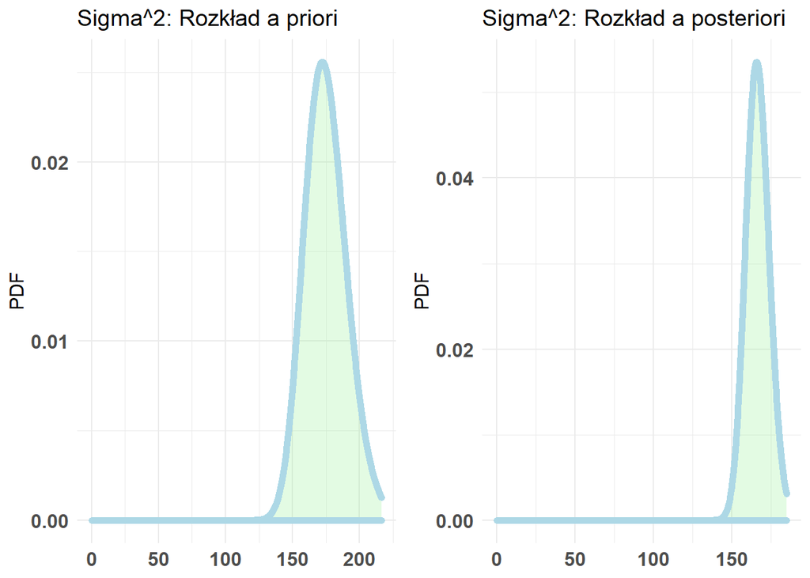

```r
plot0 = plotInvGamma(shape = alfa0/2, scale = delta0/2) +
  ggtitle('Sigma^2: Rozkład a priori')
plot1 = plotInvGamma(shape = prms$alfa1/2, scale = prms$delta1/2) +
  ggtitle('Sigma^2: Rozkład a posteriori')

grid.arrange(nrow = 1, plot0,plot1)
```

Widoczne na powyższych wykresach są podobieńśtwa pomiędzy rozkładami, jednakże w rozkładzie a posteriori pewność jest niemal dwukrotnie większa. Przedziały na nowych danych są nieznacznie mniejsze od danych a priori.

Poniżej zaprezentowano rozkłady poszczególnych zmiennych dla rozkładu a priori oraz a posteriori, gdzie wykorzystano rozkład t-studenta, ponieważ korzystano z parametrów ze “starych” badań i modelu. Skalowalne parametry tego rozkładu obliczono przy pomocy funkcji:

```r
scale_fun <- function(alpha, delta, sigma){
  scale_fun <- delta/alpha*sigma
  return(scale_fun)
}
```

#### Dane a priori:

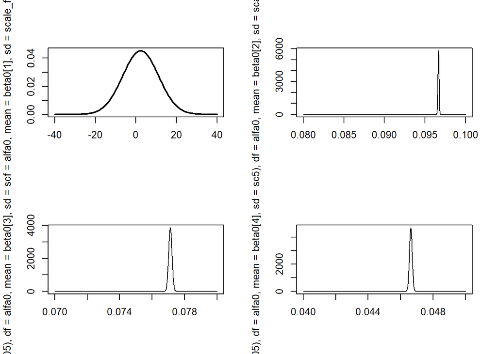

```r
par(mfrow=c(2,2))
plot(dt.scaled(x=seq(-40,40), df=alfa0, mean = beta0[1], sd=scale_fun(alfa0, delta0, sigma0[1,1])), x=seq(-40,40), type='l', lwd=2, xlab = "")
plot(dt.scaled(x=seq(0.08,0.1,0.00001), df=alfa0, mean = beta0[2], sd=scale_fun(alfa0, delta0, sigma0[2,2])), type='l',x=seq(0.08,0.1,0.00001), xlab="")
plot(dt.scaled(x=seq(0.07,0.08,0.00001), df=alfa0, mean = beta0[3], sd=scale_fun(alfa0, delta0, sigma0[3,3])), type='l', x=seq(0.07,0.08,0.00001), xlab="")
plot(dt.scaled(x=seq(0.04,0.05,0.00001), df=alfa0, mean = beta0[4], sd=scale_fun(alfa0, delta0, sigma0[4,4])), type='l', x=seq(0.04,0.05,0.00001), xlab = "")
```

#### Dane a posteriori:

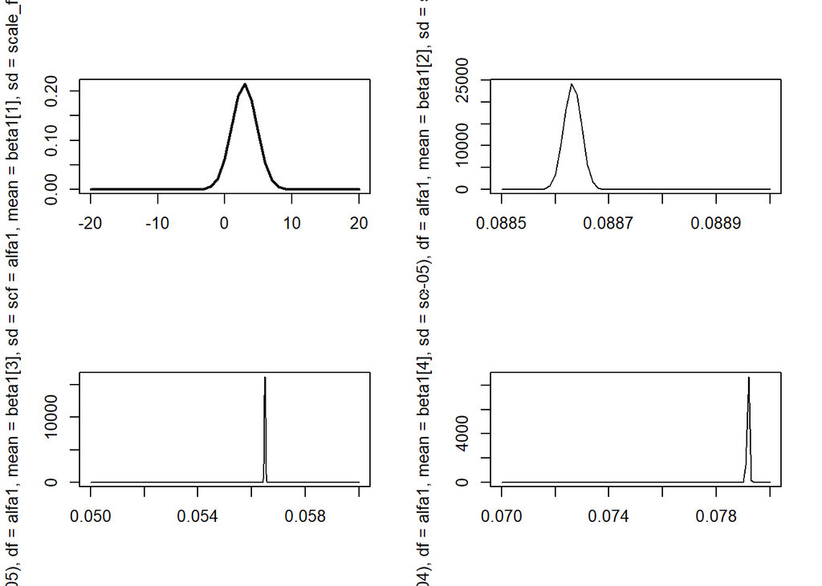

```r
par(mfrow=c(2,2))
plot(dt.scaled(x=seq(-20,20), df=alfa1, mean = beta1[1], sd=scale_fun(alfa1, delta1, sigma1[1,1])), type='l', x=seq(-20,20), xlab="", lwd=2)
plot(dt.scaled(x=seq(0.0885,0.089,0.00001), df=alfa1, mean = beta1[2], sd=scale_fun(alfa1, delta1, sigma1[2,2])), type='l', x=seq(0.0885,0.089,0.00001), xlab="")
plot(dt.scaled(x=seq(0.05,0.06,0.00001), df=alfa1, mean = beta1[3], sd=scale_fun(alfa1, delta1, sigma1[3,3])), type='l', x=seq(0.05,0.06,0.00001), xlab="")
plot(dt.scaled(x=seq(0.07,0.08,0.0001), df=alfa1, mean = beta1[4], sd=scale_fun(alfa1, delta1, sigma1[4,4])), type='l', xlab = "", x=seq(0.07,0.08,0.0001))
```

## Bayesowskie estymatory parametrów modelu

### Wartości estymatora

W kolejnym kroku obliczono estymator bayesowski dla każdej wartości wektora beta1.

```r
BayBeta <- as.vector(prms$beta1)
columns <- names(MNKBeta)
names(BayBeta) <- columns
BayBeta
```

```
## (Intercept)      Cement         BFS         Age
##  2.92463259  0.08863231  0.05649554  0.07918036
```

Wyznaczone parametry można estymować w następujący sposób:

- Wzrost ilości cementu o 1 kg w 1 m^3 betonu sprawi że będzie on wytrzymalszy o 0,09 MPa (ceteris paribus)
- Wraz z przyrostem ilości żużlu o 1 kg w 1 m^3 betonu, mieszanka będzie on wytrzymalsza o 0,06 MPa (ceteris paribus)
- Z każdym dniem wiązania mieszanki betonu, będzie on wytrzymalszy o 0,07 MPa (ceteris paribus)

### HDPI

Celem weryfikacji istotności powyższych parametrów wyznaczono ich HPDI *(Highest Posterior Density Interval)*. Kluczowe dla istotności parametrów jest, aby żaden przedział nie zawierał zera.

```r
hdi(rt.scaled(n=1000, df=alfa1, mean = beta1[1], sd=scale_fun(alfa1, delta1, sigma1[1,1])))
```

```
##     lower     upper
## -1.148547  6.048489
## attr(,"credMass")
## [1] 0.95
```

```r
hdi(rt.scaled(n=1000, df=alfa1, mean = beta1[2], sd=scale_fun(alfa1, delta1, sigma1[2,2])))
```

```
##      lower      upper
## 0.08860235 0.08866332
## attr(,"credMass")
## [1] 0.95
```

```r
hdi(rt.scaled(n=1000, df=alfa1, mean = beta1[3], sd=scale_fun(alfa1, delta1, sigma1[3,3])))
```

```
##      lower      upper
## 0.05644460 0.05653937
## attr(,"credMass")
## [1] 0.95
```

```r
hdi(rt.scaled(n=1000, df=alfa1, mean = beta1[4], sd=scale_fun(alfa1, delta1, sigma1[4,4])))
```

```
##      lower      upper
## 0.07909830 0.07926081
## attr(,"credMass")
## [1] 0.95
```

Jedyny przedział zawierający w sobie zero to ten opisujący stałą w modelu. Interpretować to należy jako jej brak istotności statystycznej co pokrywa się z pierwszym wyestymowanym modelem opartym na danych a priori.

### Porównanie

Poniżej zestawiono ze sobą wartości parametrów uzyskane metodą najmniejszych kwadratów oraz bayesowską.

```r
MNKBeta # Metoda najmniejszych kwadratów:
```

```
## (Intercept)      Cement         BFS         Age
##  5.96240049  0.07496257  0.04042762  0.10625650
```

```r
BayBeta # Metoda Bayesowska
```

```
## (Intercept)      Cement         BFS         Age
##  2.92463259  0.08863231  0.05649554  0.07918036
```

Co istotne, odnotowano dużą zmianę wartości dla stałej w modelu, jednak pozostałe parametry są na zbliżonym poziomie

## Prognozy

Celem stworzenia prognoz Bayesowskich wyznaczono w pierwszym kroku rozkłady predykcyjne. Prognozy zostały obliczone dla pięciu obserwacji zawartych w osobnym zbiorze danych testowych.

### Rozkłady predykcyjne

```r
alfa1 <- prms$alfa1

Xt <- matrix(data = c( rep(1, nrow(data_test)) , data_test$Cement, data_test$BFS, data_test$Age ), ncol = 4)
ex <- Xt %*% as.matrix(prms$beta1)

scale <- (prms$delta1 / alfa1) * (diag(1,ncol = nrow(data_test), nrow =nrow(data_test) ) +  Xt %*% as.matrix(prms$sigma1) %*% t(Xt) )


brzegoweY <- list()

for (i in 1:length(ex)){

  brzegoweY <- c(brzegoweY, list(c(ex = ex[i], scale = scale[i,i], alfa = alfa1)))
  names(brzegoweY)[i] <- paste0("yp", as.character(i))
}
```

Rozkłady predykcyjne dla Y prezentują się następująco:

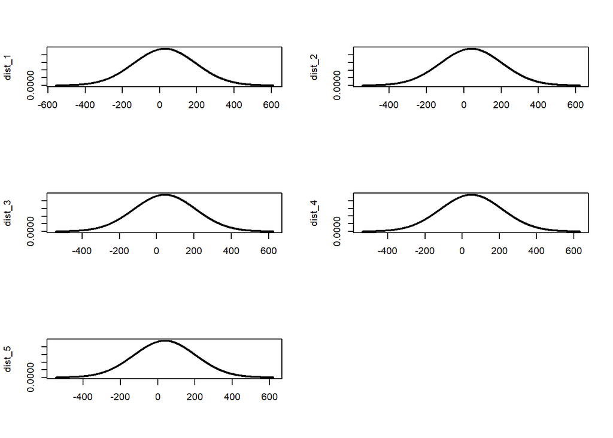

```r
library(pls)
par(mfrow=c(3,2))

pred_plot = function(brzegoweY, yp,sequence_x){
  dist_y <- dt.scaled(df = brzegoweY[[yp]][[3]], mean = brzegoweY[[yp]][[1]], sd = brzegoweY[[yp]][[2]], x = sequence_x )
}


dist_1 = pred_plot(brzegoweY,"yp1", seq(brzegoweY[["yp1"]][[1]] - 3.5 * brzegoweY[["yp1"]][[2]],
                                         brzegoweY[["yp1"]][[1]] + 3.5 * brzegoweY[["yp1"]][[2]]))
plot(dist_1, x = seq(brzegoweY[["yp1"]][[1]] - 3.5 * brzegoweY[["yp1"]][[2]],
                     brzegoweY[["yp1"]][[1]] + 3.5 * brzegoweY[["yp1"]][[2]]),
     xlab = "", type = "l", lwd = 2)

dist_2 = pred_plot(brzegoweY,"yp2", seq(brzegoweY[["yp2"]][[1]] - 3.5 * brzegoweY[["yp2"]][[2]],
                                         brzegoweY[["yp2"]][[1]] + 3.5 * brzegoweY[["yp2"]][[2]]))
plot(dist_2, x = seq(brzegoweY[["yp2"]][[1]] - 3.5 * brzegoweY[["yp2"]][[2]],
                     brzegoweY[["yp2"]][[1]] + 3.5 * brzegoweY[["yp2"]][[2]]),
     xlab = "", type = "l", lwd = 2)

dist_3 = pred_plot(brzegoweY,"yp3", seq(brzegoweY[["yp3"]][[1]] - 3.5 * brzegoweY[["yp3"]][[2]],
                                         brzegoweY[["yp3"]][[1]] + 3.5 * brzegoweY[["yp3"]][[2]]))
plot(dist_3, x = seq(brzegoweY[["yp3"]][[1]] - 3.5 * brzegoweY[["yp3"]][[2]],
                     brzegoweY[["yp3"]][[1]] + 3.5 * brzegoweY[["yp3"]][[2]]),
     xlab = "", type = "l", lwd = 2)

dist_4 = pred_plot(brzegoweY,"yp4", seq(brzegoweY[["yp4"]][[1]] - 3.5 * brzegoweY[["yp4"]][[2]],
                                         brzegoweY[["yp4"]][[1]] + 3.5 * brzegoweY[["yp4"]][[2]]))
plot(dist_4, x = seq(brzegoweY[["yp4"]][[1]] - 3.5 * brzegoweY[["yp4"]][[2]],
                     brzegoweY[["yp4"]][[1]] + 3.5 * brzegoweY[["yp4"]][[2]]),
     xlab = "", type = "l", lwd = 2)
dist_5 = pred_plot(brzegoweY,"yp5", seq(brzegoweY[["yp5"]][[1]] - 3.5 * brzegoweY[["yp5"]][[2]],
                                         brzegoweY[["yp5"]][[1]] + 3.5 * brzegoweY[["yp5"]][[2]]))
plot(dist_5, x = seq(brzegoweY[["yp5"]][[1]] - 3.5 * brzegoweY[["yp5"]][[2]],
                     brzegoweY[["yp5"]][[1]] + 3.5 * brzegoweY[["yp5"]][[2]]),
     xlab = "", type = "l", lwd = 2)
```

Warto zauważyć, że wszystkie rozkłady predykcji wyglądają bardzo podobnie, na co duży wpływ ma podobieństwo obserwacji testowych.

### Prognozy wartości

W poniższej tabeli zawarto porównanie prognoz uzyskanych za pomocą metody Bayesa z probnozami uzyskanymi MNK oraz wartościami rzeczywistymi.

```r
MNK_pred <- predict(modelMNK,data_test)
dot = data.frame(MNK = MNK_pred, Bayes=ex, rzeczywiste = data_test[,4])
dot%>% kable() %>% kable_styling()
```

| MNK | Bayes | CCS |
| --- | --- | --- |
| 26.31001 | 27.13076 | 44.61186 |
| 36.80810 | 39.28757 | 53.52471 |
| 39.66127 | 42.89581 | 57.21823 |
| 43.93385 | 48.14577 | 65.90908 |
| 35.12323 | 37.22328 | 52.82696 |

Wartości rzeczywiste znacząco odbiegają od wartości obliczonych metodą MNK oraz Bayesowską. Co istotne, w obu przypadkach prognozy są zaniżone.

W kolejnym kroku wyznaczono HDPI dla prognoz, których wyniki zawarto poniżej:

```r
hpdi.Y <- list()

for( i in 1:length(brzegoweY)) {
  temp <- hdi(rt.scaled(n = 1000,df = brzegoweY[[i]][[3]], mean = brzegoweY[[i]][[1]], sd = brzegoweY[[i]][[2]]))
  hpdi.Y <- c(hpdi.Y, list(c(temp[1], temp[2])))
  names(hpdi.Y)[i] <- paste0("hpdi.Y", as.character(i))
}

lower <- c()
upper <- c()
for(i in 1:length(hpdi.Y)){
  lower[i] = hpdi.Y[[i]][[1]]
  upper[i] = hpdi.Y[[i]][[2]]
}
BayesprogInterval <- data.frame(Low=lower,Up=upper)

MNKprogInterval <- predict(modelMNK,data_test,interval = "confidence")

interv = data.frame(MNK = MNKprogInterval[,2:3],Bayes=BayesprogInterval)
interv%>% kable() %>% kable_styling()
```

| MNK.lwr | MNK.upr | Bayes.Low | Bayes.Up |
| --- | --- | --- | --- |
| 24.74480 | 27.87522 | -328.7053 | 311.9881 |
| 35.42594 | 38.19027 | -295.7064 | 363.5579 |
| 37.89778 | 41.42476 | -293.2716 | 368.8645 |
| 41.64996 | 46.21773 | -294.2933 | 338.7694 |
| 33.88982 | 36.35663 | -267.7846 | 377.0936 |

Wnioskiem płynącym z powyższych wartości jest bardzo duża róznica szerokości przedziałów dla MNK i Bayesa. Przedziały z metody bayesowskiej są o wiele szersze tj charakteryzują się dużym rozstępem.

W następnym kroku wyznaczono błędy prognozy.

```r
RMSE_MNK <- rmse(dot$CCS,dot$MNK)
MAE_MNK <- mae(dot$CCS,dot$MNK)
MAPE_MNK<-mape(dot$CCS,dot$MNK)


RMSE_Bayes<-rmse(dot$CCS,dot$Bayes)
MAE_Bayes<- mae(dot$CCS,dot$Bayes)
MAPE_Bayes<-mape(dot$CCS,dot$Bayes)

bledy <- data.frame(RMSE = c(RMSE_MNK,RMSE_Bayes), MAE = c(MAE_MNK,MAE_Bayes), MAPE = c(MAPE_MNK,MAPE_Bayes), row.names = c("MNK", "BAYES"))
bledy %>% kable() %>% kable_styling()
```

|  | RMSE | MAE | MAPE |
| --- | --- | --- | --- |
| MNK | 18.54175 | 18.45088 | 0.3395896 |
| BAYES | 15.95260 | 15.88153 | 0.2946077 |

Wskazują one jasno na przewagę metody Bayesa nad MNK, ponieważ wszystkie wartości są mniejsze dla tego sposobu modelowania.

## Istotność zmiennych

```r
model0R <- lm(data = data_apriori, CCS ~ Age + Cement)
summary.0R <- summary(model0R)

beta0R <- as.vector(model0R$coefficients)

X0R <- matrix(data = c( rep(1, 100) , data_apriori$Cement,  data_apriori$Age), ncol = 3)
sigma0R <- solve(t(X0R) %*% X0R)

alfa0R <- nrow(data_apriori)-ncol(data_apriori)-2
delta0R <- sum(model0R$residuals^2)

X <- matrix(data = c( rep(1, nrow(data)) , data$Cement, data$Age), ncol = 3)
sigm <- as.matrix(sigma0R)
y <- as.matrix(data$CCS)

sigm1 <- solve( t(X) %*% X + solve(sigm))

beta1 <- sigm1 %*% ( t(X) %*% y + solve(sigm) %*% beta0R)

alfa1 <- alfa0R + nrow(data)
delta1 <- delta0R + t(y) %*% y - t(beta1) %*% solve(sigm1) %*% beta1 + t(beta0R)%*%solve(sigm)%*%beta0R

prms_res = list(alfa1 = alfa1, delta1 = as.numeric(delta1), sigma1 = sigm1, beta1 = beta1)

pyM1_p1 <- sqrt(det(sigma0)/det(prms$sigma1))
pyM2_p1 <- sqrt(det(sigma0R)/det(prms_res$sigma1))
part1 <- pyM1_p1/pyM2_p1

alpha.1=nrow(data_apriori)+nrow(data)-ncol(data_apriori)

alpha.0=nrow(data_apriori)-ncol(data_apriori)

part2 <- ((delta0/delta0R)^alpha.0)*delta0*((prms_res$delta1/prms$delta1)^alpha.1)/prms$delta1
part3 <- alpha.1/alpha.0

R12 <- part1*part2*part3
```

Zatem wartość logarytmu ilorazu szans wynosi:

```r
log(R12)
```

```
## [1] 67.8157
```

```r
linearHypothesis(modelMNK, c("Age=0", "BFS=0"))
```

```
## Linear hypothesis test
##
## Hypothesis:
## Age = 0
## BFS = 0
##
## Model 1: restricted model
## Model 2: CCS ~ Cement + BFS + Age
##
##   Res.Df    RSS Df Sum of Sq      F    Pr(>F)
## 1    748 140517
## 2    746 115600  2     24917 80.398 < 2.2e-16 ***
## ---
## Signif. codes:  0 '***' 0.001 '**' 0.01 '*' 0.05 '.' 0.1 ' ' 1
```

Przeprowadzony test dał w rezultacie bardzo niskie p-value, co potwierdza wniosek o przewadze modelu bez restrykcji oraz jego poprawność.